# cardinal fitness — results summaries

## Statistical Methods

All analyses were performed in R (v4.5.2). Fecundity (egg counts) was modelled using a zero-inflated negative binomial mixed model fitted with glmmTMB, with cross direction and genetic line as fixed effects and replicate and plate well as nested random effects. Hatching rate was modelled using a binomial generalised linear mixed model (GLMM), also fitted with glmmTMB. Estimated marginal means and pairwise contrasts were obtained using emmeans. Post-blood-feeding survival, trans-heterozygote survival, and XA supplementation survival data were modelled using Weibull parametric survival models fitted with flexsurv. Midgut integrity (smurf assay) and adult eclosion data were modelled using binomial generalised linear models (GLMs) fitted with base R glm(). Gene expression data were analysed using the delta-delta-Ct method; ΔCt levels were modelled with a permutation-based linear model using emmeans for contrasts. Model tables were produced using sjPlot. Survival curves were visualised using Kaplan–Meier estimates alongside Weibull model predictions. All figures were produced using ggplot2 and patchwork.

## Fecundity

|  | eggs |  |  |  |
| --- | --- | --- | --- | --- |
| Predictors | Incidence Rate Ratios | CI | p |  |
| Count Model |  |  |  |  |
| Intercept (QA383P, SDA×SDA) | 76.59 | 62.78 – 93.45 | **<0.001** |  |
| *cd*<sup>g225</sup> | 1.09 | 0.85 – 1.41 | 0.490 |  |
| *cd*<sup>g384</sup> | 1.48 | 1.18 – 1.85 | **0.001** |  |
| Female Het | 1.31 | 1.03 – 1.67 | **0.029** |  |
| Male Het | 1.12 | 0.86 – 1.46 | 0.416 |  |
| Female Hom | 1.43 | 1.09 – 1.88 | **0.009** |  |
| Male Hom | 0.74 | 0.53 – 1.04 | 0.084 |  |
| *cd*<sup>g225</sup> × Female Het | 1.00 | NaN – NaN | NaN |  |
| *cd*<sup>g384</sup> × Female Het | 0.63 | 0.47 – 0.86 | **0.004** |  |
| *cd*<sup>g225</sup> × Male Het | 0.90 | 0.62 – 1.31 | 0.569 |  |
| *cd*<sup>g384</sup> × Male Het | 0.80 | 0.59 – 1.10 | 0.177 |  |
| *cd*<sup>g384</sup> × Female Hom | 0.41 | 0.28 – 0.59 | **<0.001** |  |
| *cd*<sup>g384</sup> × Male Hom | 0.79 | 0.50 – 1.25 | 0.316 |  |
| Intercept (QA383P, SDA×SDA) | 9534217.44 | 196910.85 – 1587058406.93 |  |  |
| Zero-Inflated Model |  |  |  |  |
| Intercept (QA383P, SDA×SDA) | 0.47 | 0.39 – 0.56 | **<0.001** |  |
| Random Effects |  |  |  |  |
| σ<sup>2</sup> |  |  |  |  |
| τ<sub>00</sub> <sub>plate_well:rep</sub> | 0.05 |  |  |  |
| τ<sub>00</sub> <sub>rep</sub> | 0.00 |  |  |  |
| N <sub>plate_well</sub> | 506 |  |  |  |
| N <sub>rep</sub> | 10 |  |  |  |
| Observations | 546 |  |  |  |

| Line | Cross | Non-zero wells Conditional mean | Non-zero wells Lower 95% CI | Non-zero wells Upper 95% CI | Expected count (incl. zeros)<sup>1</sup> |  |
| --- | --- | --- | --- | --- | --- | --- |
| *cd*<sup>384R</sup> | WT | 76.6 | 62.8 | 93.4 |  | 52.2 |
| *cd*<sup>g225</sup> | WT | 83.7 | 71.6 | 97.9 | 57.0 |  |
| *cd*<sup>g384</sup> | WT | 113.4 | 102.2 | 125.9 | 77.3 |  |
| *cd*<sup>384R</sup> | Female HET | 100.5 | 87.1 | 115.8 | 68.4 |  |
| *cd*<sup>g225</sup> | Female HET | 109.7 | NaN | NaN | 74.8 |  |
| *cd*<sup>g384</sup> | Female HET | 94.4 | 80.1 | 111.2 | 64.3 |  |
| *cd*<sup>384R</sup> | Male HET | 85.5 | 71.6 | 102.2 | 58.3 |  |
| *cd*<sup>g225</sup> | Male HET | 83.8 | 67.5 | 104.0 | 57.1 |  |
| *cd*<sup>g384</sup> | Male HET | 101.8 | 88.4 | 117.2 | 69.4 |  |
| *cd*<sup>384R</sup> | Female HOM | 109.9 | 91.1 | 132.4 | 74.8 |  |
| *cd*<sup>g225</sup> | Female HOM | NA | NA | NA | NA |  |
| *cd*<sup>g384</sup> | Female HOM | 66.5 | 53.2 | 83.2 | 45.3 |  |
| *cd*<sup>384R</sup> | Male HOM | 56.9 | 43.4 | 74.7 | 38.8 |  |
| *cd*<sup>g225</sup> | Male HOM | NA | NA | NA | NA |  |
| *cd*<sup>g384</sup> | Male HOM | 66.7 | 49.9 | 89.3 | 45.5 |  |

<sup>1</sup> Structural zero probability = 0.319; expected count = conditional mean × (1 − p_zero)

| Line comparisons within cross Contrast | Line comparisons within cross Cross | Line comparisons within cross IRR | Line comparisons within cross Lower 95% CI | Line comparisons within cross Upper 95% CI | Line comparisons within cross z | Line comparisons within cross p |
| --- | --- | --- | --- | --- | --- | --- |
| *cd*<sup>384R</sup> - *cd*<sup>g225</sup> | WT | 0.91 | 0.71 | 1.18 | −0.69 | 0.769 |
| *cd*<sup>384R</sup> - *cd*<sup>g384</sup> | WT | 0.68 | 0.54 | 0.84 | −3.45 | 0.002 |
| *cd*<sup>g225</sup> - *cd*<sup>g384</sup> | WT | 0.74 | 0.61 | 0.89 | −3.19 | 0.004 |
| *cd*<sup>384R</sup> - *cd*<sup>g384</sup> | Female HET | 1.06 | 0.86 | 1.32 | 0.57 | 0.568 |
| *cd*<sup>384R</sup> - *cd*<sup>g225</sup> | Male HET | 1.02 | 0.77 | 1.35 | 0.14 | 0.989 |
| *cd*<sup>384R</sup> - *cd*<sup>g384</sup> | Male HET | 0.84 | 0.67 | 1.05 | −1.52 | 0.283 |
| *cd*<sup>g225</sup> - *cd*<sup>g384</sup> | Male HET | 0.82 | 0.64 | 1.06 | −1.49 | 0.297 |
| *cd*<sup>384R</sup> - *cd*<sup>g384</sup> | Female HOM | 1.65 | 1.24 | 2.21 | 3.40 | <0.001 |
| *cd*<sup>384R</sup> - *cd*<sup>g384</sup> | Male HOM | 0.85 | 0.57 | 1.27 | −0.78 | 0.433 |

| Cross comparisons within line Contrast | Cross comparisons within line Line | Cross comparisons within line IRR | Cross comparisons within line Lower 95% CI | Cross comparisons within line Upper 95% CI | Cross comparisons within line z | Cross comparisons within line p |
| --- | --- | --- | --- | --- | --- | --- |
| WT - Female HET | *cd*<sup>384R</sup> | 0.76 | 0.60 | 0.97 | −2.19 | 0.184 |
| WT - Male HET | *cd*<sup>384R</sup> | 0.90 | 0.69 | 1.17 | −0.81 | 0.927 |
| WT - Female HOM | *cd*<sup>384R</sup> | 0.70 | 0.53 | 0.91 | −2.60 | 0.070 |
| WT - Male HOM | *cd*<sup>384R</sup> | 1.35 | 0.96 | 1.88 | 1.73 | 0.415 |
| Female HET - Male HET | *cd*<sup>384R</sup> | 1.17 | 0.94 | 1.47 | 1.40 | 0.630 |
| Female HET - Female HOM | *cd*<sup>384R</sup> | 0.91 | 0.72 | 1.15 | −0.75 | 0.943 |
| Female HET - Male HOM | *cd*<sup>384R</sup> | 1.77 | 1.30 | 2.40 | 3.63 | 0.003 |
| Male HET - Female HOM | *cd*<sup>384R</sup> | 0.78 | 0.60 | 1.01 | −1.91 | 0.310 |
| Male HET - Male HOM | *cd*<sup>384R</sup> | 1.50 | 1.09 | 2.08 | 2.46 | 0.100 |
| Female HOM - Male HOM | *cd*<sup>384R</sup> | 1.93 | 1.39 | 2.68 | 3.91 | <0.001 |
| WT - Male HET | *cd*<sup>g225</sup> | 1.00 | 0.77 | 1.30 | −0.01 | 0.994 |
| WT - Female HET | *cd*<sup>g384</sup> | 1.20 | 0.99 | 1.45 | 1.88 | 0.325 |
| WT - Male HET | *cd*<sup>g384</sup> | 1.11 | 0.94 | 1.32 | 1.23 | 0.737 |
| WT - Female HOM | *cd*<sup>g384</sup> | 1.70 | 1.34 | 2.18 | 4.28 | <0.001 |
| WT - Male HOM | *cd*<sup>g384</sup> | 1.70 | 1.25 | 2.31 | 3.37 | 0.007 |
| Female HET - Male HET | *cd*<sup>g384</sup> | 0.93 | 0.75 | 1.15 | −0.69 | 0.958 |
| Female HET - Female HOM | *cd*<sup>g384</sup> | 1.42 | 1.08 | 1.87 | 2.49 | 0.092 |
| Female HET - Male HOM | *cd*<sup>g384</sup> | 1.41 | 1.01 | 1.97 | 2.04 | 0.248 |
| Male HET - Female HOM | *cd*<sup>g384</sup> | 1.53 | 1.18 | 1.99 | 3.18 | 0.013 |
| Male HET - Male HOM | *cd*<sup>g384</sup> | 1.53 | 1.10 | 2.11 | 2.56 | 0.077 |
| Female HOM - Male HOM | *cd*<sup>g384</sup> | 1.00 | 0.69 | 1.44 | −0.02 | 1.000 |

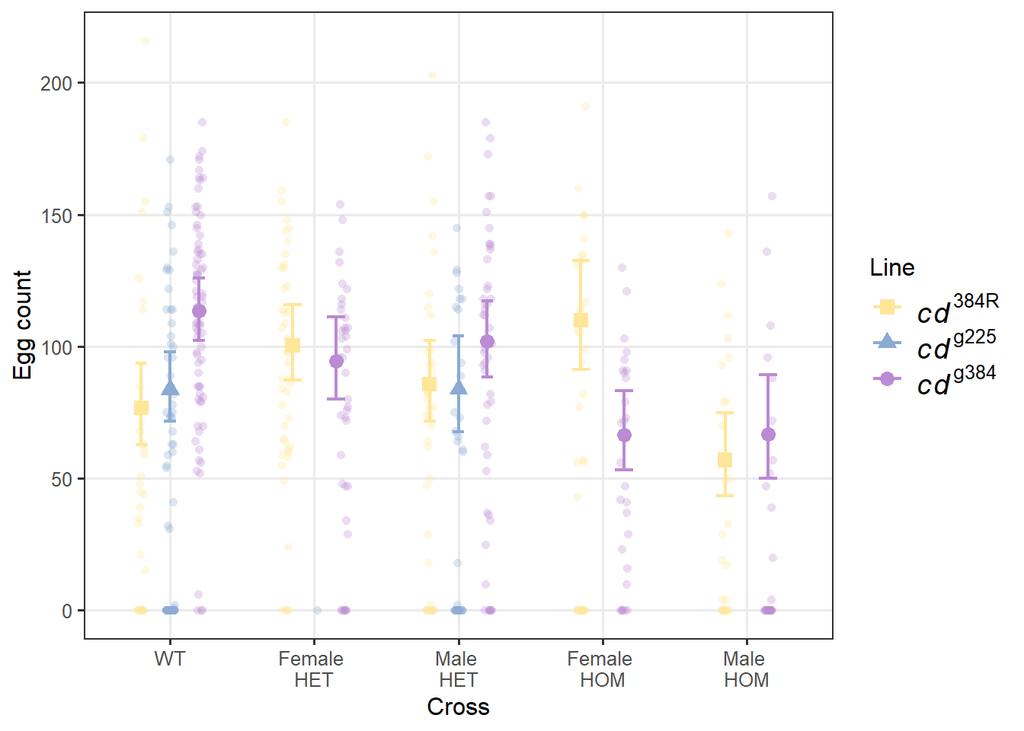

## Fertility

|  | cbind(larvae,(eggs-larvae)) |  |  |
| --- | --- | --- | --- |
| Predictors | Odds Ratios | CI | p |
| Intercept (QA383P, SDA×SDA) | 4.21 | 2.16 – 8.22 | **<0.001** |
| *cd*<sup>g225</sup> | 0.88 | 0.37 – 2.09 | 0.772 |
| *cd*<sup>g384</sup> | 1.28 | 0.59 – 2.77 | 0.539 |
| Female Het | 4.51 | 1.91 – 10.65 | **0.001** |
| Male Het | 2.02 | 0.81 – 5.07 | 0.132 |
| Female Hom | 2.96 | 1.11 – 7.88 | **0.030** |
| Male Hom | 1.92 | 0.66 – 5.61 | 0.230 |
| *cd*<sup>g384</sup> × Female Het | 0.15 | 0.05 – 0.45 | **0.001** |
| line2360B5:crossMale HET | 0.37 | 0.10 – 1.35 | 0.131 |
| *cd*<sup>g384</sup> × Male Het | 0.31 | 0.10 – 0.96 | **0.043** |
| *cd*<sup>g384</sup> × Female Hom | 0.00 | 0.00 – 0.01 | **<0.001** |
| *cd*<sup>g384</sup> × Male Hom | 0.30 | 0.07 – 1.31 | 0.108 |
| Random Effects |  |  |  |
| σ<sup>2</sup> | 2.76 |  |  |
| τ<sub>00</sub> <sub>plate_well:rep:line</sub> | 2.72 |  |  |
| τ<sub>00</sub> <sub>rep:line</sub> | 0.00 |  |  |
| τ<sub>00</sub> <sub>line</sub> | 0.00 |  |  |
| N <sub>plate_well</sub> | 424 |  |  |
| N <sub>rep</sub> | 10 |  |  |
| N <sub>line</sub> | 3 |  |  |
| Observations | 449 |  |  |
| Marginal R<sup>2</sup> / Conditional R<sup>2</sup> | 0.323 / NA |  |  |

| Line | Cross | Estimated marginal means Hatching probability | Estimated marginal means Lower 95% CI | Estimated marginal means Upper 95% CI |
| --- | --- | --- | --- | --- |
| *cd*<sup>384R</sup> | WT | 0.808 | 0.683 | 0.892 |
| *cd*<sup>g225</sup> | WT | 0.787 | 0.681 | 0.865 |
| *cd*<sup>g384</sup> | WT | 0.843 | 0.784 | 0.888 |
| *cd*<sup>384R</sup> | Female HET | 0.950 | 0.917 | 0.970 |
| *cd*<sup>g225</sup> | Female HET | NA | NA | NA |
| *cd*<sup>g384</sup> | Female HET | 0.781 | 0.665 | 0.865 |
| *cd*<sup>384R</sup> | Male HET | 0.895 | 0.820 | 0.941 |
| *cd*<sup>g225</sup> | Male HET | 0.733 | 0.563 | 0.853 |
| *cd*<sup>g384</sup> | Male HET | 0.773 | 0.671 | 0.851 |
| *cd*<sup>384R</sup> | Female HOM | 0.926 | 0.859 | 0.962 |
| *cd*<sup>g225</sup> | Female HOM | NA | NA | NA |
| *cd*<sup>g384</sup> | Female HOM | 0.048 | 0.022 | 0.101 |
| *cd*<sup>384R</sup> | Male HOM | 0.890 | 0.779 | 0.949 |
| *cd*<sup>g225</sup> | Male HOM | NA | NA | NA |
| *cd*<sup>g384</sup> | Male HOM | 0.754 | 0.541 | 0.888 |

| Line comparisons within cross Contrast | Line comparisons within cross Cross | Line comparisons within cross OR | Line comparisons within cross Lower 95% CI | Line comparisons within cross Upper 95% CI | Line comparisons within cross z | Line comparisons within cross p |
| --- | --- | --- | --- | --- | --- | --- |
| *cd*<sup>384R</sup> - *cd*<sup>g225</sup> | WT | 1.14 | 0.48 | 2.70 | 0.29 | 0.955 |
| *cd*<sup>384R</sup> - *cd*<sup>g384</sup> | WT | 0.78 | 0.36 | 1.70 | −0.62 | 0.812 |
| *cd*<sup>g225</sup> - *cd*<sup>g384</sup> | WT | 0.69 | 0.35 | 1.35 | −1.08 | 0.527 |
| *cd*<sup>384R</sup> - *cd*<sup>g384</sup> | Female HET | 5.33 | 2.41 | 11.81 | 4.13 | <0.001 |
| *cd*<sup>384R</sup> - *cd*<sup>g225</sup> | Male HET | 3.11 | 1.17 | 8.30 | 2.27 | 0.060 |
| *cd*<sup>384R</sup> - *cd*<sup>g384</sup> | Male HET | 2.50 | 1.11 | 5.64 | 2.21 | 0.070 |
| *cd*<sup>g225</sup> - *cd*<sup>g384</sup> | Male HET | 0.80 | 0.32 | 2.00 | −0.47 | 0.885 |
| *cd*<sup>384R</sup> - *cd*<sup>g384</sup> | Female HOM | 246.12 | 84.60 | 716.03 | 10.11 | <0.001 |
| *cd*<sup>384R</sup> - *cd*<sup>g384</sup> | Male HOM | 2.65 | 0.75 | 9.41 | 1.51 | 0.132 |

| Cross comparisons within line Contrast | Cross comparisons within line Line | Cross comparisons within line OR | Cross comparisons within line Lower 95% CI | Cross comparisons within line Upper 95% CI | Cross comparisons within line z | Cross comparisons within line p |
| --- | --- | --- | --- | --- | --- | --- |
| WT - Female HET | *cd*<sup>384R</sup> | 0.22 | 0.09 | 0.52 | −3.43 | 0.005 |
| WT - Male HET | *cd*<sup>384R</sup> | 0.49 | 0.20 | 1.24 | −1.51 | 0.559 |
| WT - Female HOM | *cd*<sup>384R</sup> | 0.34 | 0.13 | 0.90 | −2.17 | 0.190 |
| WT - Male HOM | *cd*<sup>384R</sup> | 0.52 | 0.18 | 1.51 | −1.20 | 0.752 |
| Female HET - Male HET | *cd*<sup>384R</sup> | 2.23 | 0.97 | 5.10 | 1.89 | 0.320 |
| Female HET - Female HOM | *cd*<sup>384R</sup> | 1.52 | 0.62 | 3.73 | 0.92 | 0.889 |
| Female HET - Male HOM | *cd*<sup>384R</sup> | 2.34 | 0.87 | 6.33 | 1.68 | 0.448 |
| Male HET - Female HOM | *cd*<sup>384R</sup> | 0.68 | 0.26 | 1.77 | −0.78 | 0.936 |
| Male HET - Male HOM | *cd*<sup>384R</sup> | 1.05 | 0.37 | 2.99 | 0.09 | 1.000 |
| Female HOM - Male HOM | *cd*<sup>384R</sup> | 1.54 | 0.51 | 4.62 | 0.77 | 0.940 |
| WT - Male HET | *cd*<sup>g225</sup> | 1.35 | 0.53 | 3.44 | 0.63 | 0.526 |
| WT - Female HET | *cd*<sup>g384</sup> | 1.51 | 0.75 | 3.04 | 1.15 | 0.781 |
| WT - Male HET | *cd*<sup>g384</sup> | 1.57 | 0.82 | 3.01 | 1.37 | 0.645 |
| WT - Female HOM | *cd*<sup>g384</sup> | 106.02 | 43.85 | 256.32 | 10.35 | <0.001 |
| WT - Male HOM | *cd*<sup>g384</sup> | 1.76 | 0.63 | 4.92 | 1.07 | 0.822 |
| Female HET - Male HET | *cd*<sup>g384</sup> | 1.04 | 0.48 | 2.28 | 0.11 | 1.000 |
| Female HET - Female HOM | *cd*<sup>g384</sup> | 70.29 | 26.25 | 188.21 | 8.46 | <0.001 |
| Female HET - Male HOM | *cd*<sup>g384</sup> | 1.16 | 0.38 | 3.56 | 0.27 | 0.999 |
| Male HET - Female HOM | *cd*<sup>g384</sup> | 67.36 | 26.17 | 173.41 | 8.73 | <0.001 |
| Male HET - Male HOM | *cd*<sup>g384</sup> | 1.12 | 0.38 | 3.30 | 0.20 | 1.000 |
| Female HOM - Male HOM | *cd*<sup>g384</sup> | 0.02 | 0.00 | 0.06 | −6.49 | <0.001 |

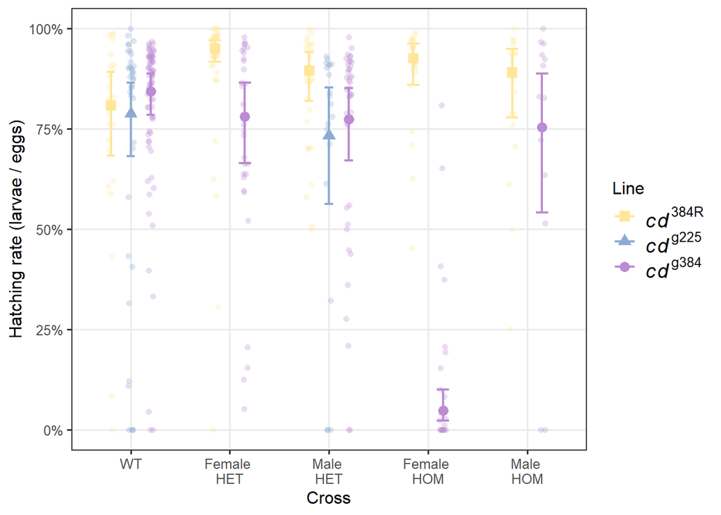

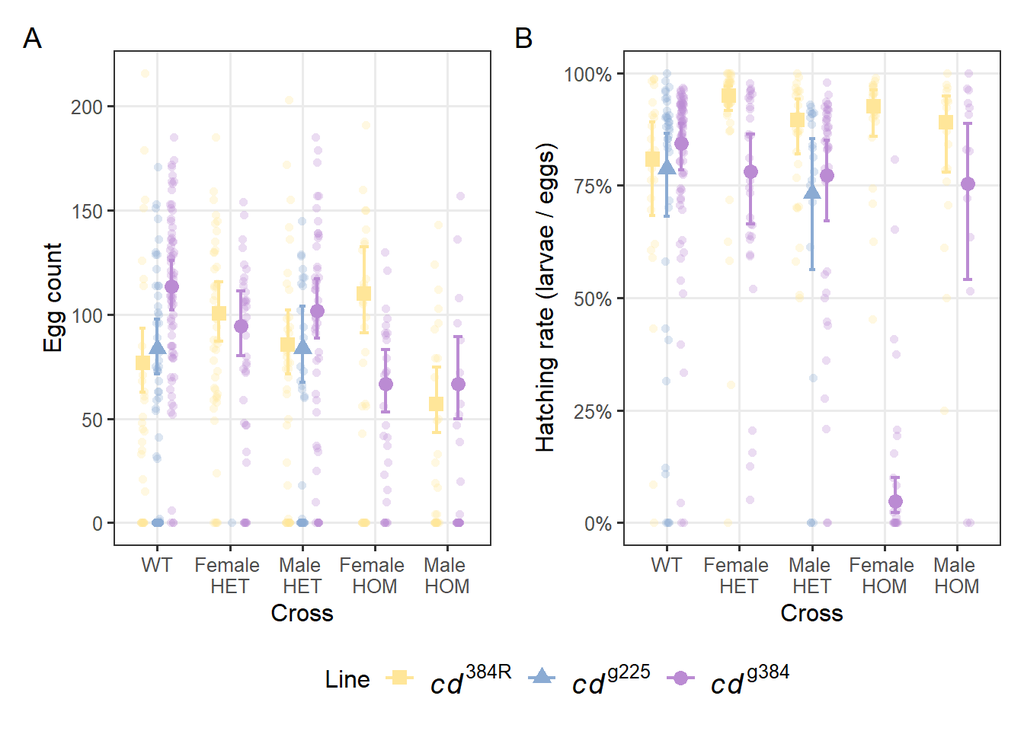

## Survival after Blood Feeding

```
`r2()` does not support models of class `flexsurvreg`.
```

[output not shown]

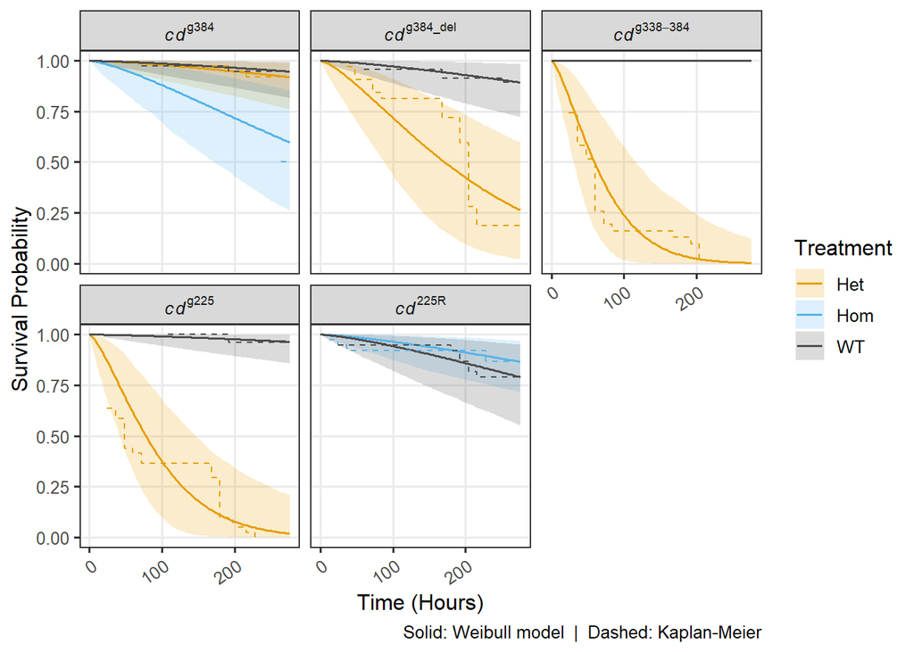

# Median survival (t50) by group

| Line | Genotype | Median survival time Median survival (h) | Median survival time Lower 95% CI | Median survival time Upper 95% CI |
| --- | --- | --- | --- | --- |
| *cd*<sup>g384</sup> | WT | 1,755.4 | 884.4 | 3,313.3 |
| *cd*<sup>g384</sup> | Het | 1,282.9 | 662.0 | 2,510.3 |
| *cd*<sup>g384</sup> | Hom | 342.4 | 176.7 | 640.9 |
| *cd*<sup>g225</sup> | WT | 2,354.6 | 1,175.0 | 4,677.5 |
| *cd*<sup>g225</sup> | Het | 77.6 | 38.7 | 144.1 |
| *cd*<sup>g384del</sup> | WT | 1,029.9 | 518.0 | 1,958.0 |
| *cd*<sup>g384del</sup> | Het | 171.1 | 88.5 | 331.6 |
| *cd*<sup>g338-384</sup> | WT | 444,585,617.9 | 0.0 | Inf |
| *cd*<sup>g338-384</sup> | Het | 58.9 | 31.5 | 115.8 |
| *cd*<sup>225R</sup> | Hom | 863.7 | 531.5 | 1,387.3 |
| *cd*<sup>225R</sup> | WT | 603.7 | 317.6 | 1,141.7 |

# Survival probability at t = 300 h

| Line | Genotype | Survival probability at 300 h Survival | Survival probability at 300 h Lower 95% CI | Survival probability at 300 h Upper 95% CI |
| --- | --- | --- | --- | --- |
| *cd*<sup>g384</sup> | WT | 0.941 | 0.812 | 0.992 |
| *cd*<sup>g384</sup> | Het | 0.910 | 0.744 | 0.983 |
| *cd*<sup>g384</sup> | Hom | 0.561 | 0.251 | 0.836 |
| *cd*<sup>g225</sup> | WT | 0.960 | 0.844 | 0.995 |
| *cd*<sup>g225</sup> | Het | 0.012 | 0.000 | 0.181 |
| *cd*<sup>g384del</sup> | WT | 0.881 | 0.689 | 0.974 |
| *cd*<sup>g384del</sup> | Het | 0.223 | 0.012 | 0.566 |
| *cd*<sup>g338-384</sup> | WT | 1.000 | 0.000 | 1.000 |
| *cd*<sup>g338-384</sup> | Het | 0.001 | 0.000 | 0.109 |
| *cd*<sup>225R</sup> | Hom | 0.851 | 0.684 | 0.958 |
| *cd*<sup>225R</sup> | WT | 0.767 | 0.513 | 0.937 |

## TransHet survival

```
`r2()` does not support models of class `flexsurvreg`.
```

|  | Surv(Hours,event) |  |  |
| --- | --- | --- | --- |
| Predictors | Estimates | CI | p |
| shape | 1.335 | 0.411 – 4.334 | 0.630 |
| scale | 70.891 | 0.000 – 98038538547623231456082028620.000 | 0.894 |
| 2360B5 WT | 26.664 | 11.043 – 64.385 | **<0.001** |
| Trans-het (D251:2360 Het) | 0.969 | 0.401 – 2.340 | 0.944 |
| Het<sup>KO</sup> (D251:2360 WT) | 12218566.257 | 0.000 – Inf | 0.997 |
| Observations | 186 |  |  |

| Line | Genotype | Survival probability at 100 h Survival | Survival probability at 100 h Lower 95% CI | Survival probability at 100 h Upper 95% CI |
| --- | --- | --- | --- | --- |
| *cd*<sup>g225</sup> | Het | 0.205 | 0.000 | 0.650 |
| *cd*<sup>g225</sup> | WT | 0.980 | 0.782 | 1.000 |
| *cd*<sup>g225</sup>:*cd*<sup>225R</sup> | Het | 0.192 | 0.000 | 0.773 |
| *cd*<sup>g225</sup>:*cd*<sup>225R</sup> | WT | 1.000 | 0.000 | 1.000 |

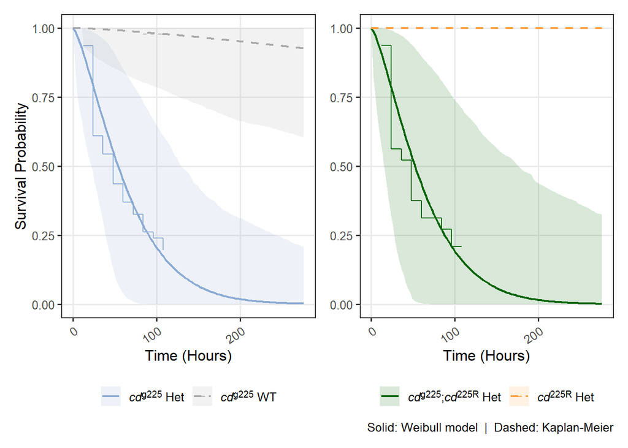

## Smurf assay

[output not shown]

| Smurf probability by genotype Genotype | Smurf probability by genotype Probability<sup>1</sup> | Smurf probability by genotype SE | Smurf probability by genotype df | Smurf probability by genotype Lower 95% CI | Smurf probability by genotype Upper 95% CI |
| --- | --- | --- | --- | --- | --- |
| WT | 0.057 | 0.025 | Inf | 0.024 | 0.129 |
| KI | 0.798 | 0.039 | Inf | 0.710 | 0.864 |
| KO | 0.000 | 0.000 | Inf | 0.000 | 1.000 |

<sup>1</sup> Probabilities back-transformed from the logit scale. Confidence level: 95%.

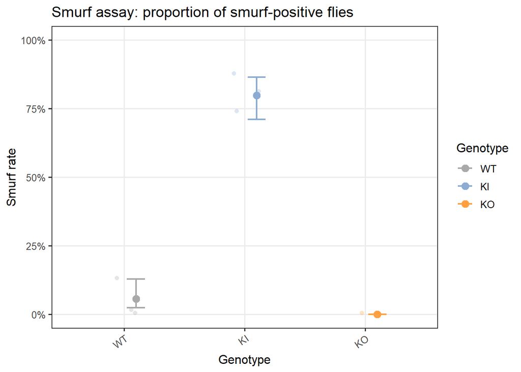

### Alternative figure as bar chart

[output not shown]

[output not shown]

[output not shown]

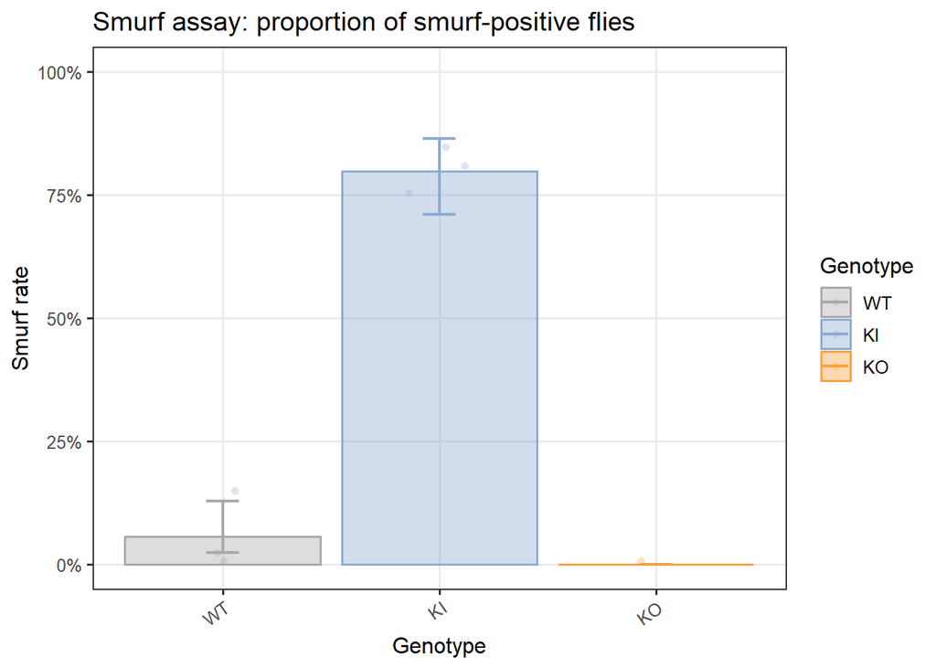

### Survival after Smurf

```
`r2()` does not support models of class `flexsurvreg`.
```

|  | Surv(hours,survival) |  |  |
| --- | --- | --- | --- |
| Predictors | Estimates | CI | p |
| shape | 2.75 | 0.40 – 18.98 | 0.305 |
| scale | 58.43 | 0.00 – 40818058648747196416.00 | 0.846 |
| line [KO] | 4900.99 | 0.00 – Inf | 0.998 |
| line [WT] | 4900.99 | 0.00 – Inf | 0.998 |
| Observations | 271 |  |  |

```
line=KO
  time est lcl ucl
1   72   1   0   1

line=KI
  time       est          lcl       ucl
1   72 0.1694089 4.460946e-08 0.8371664

line=WT
  time est lcl ucl
1   72   1   0   1
```

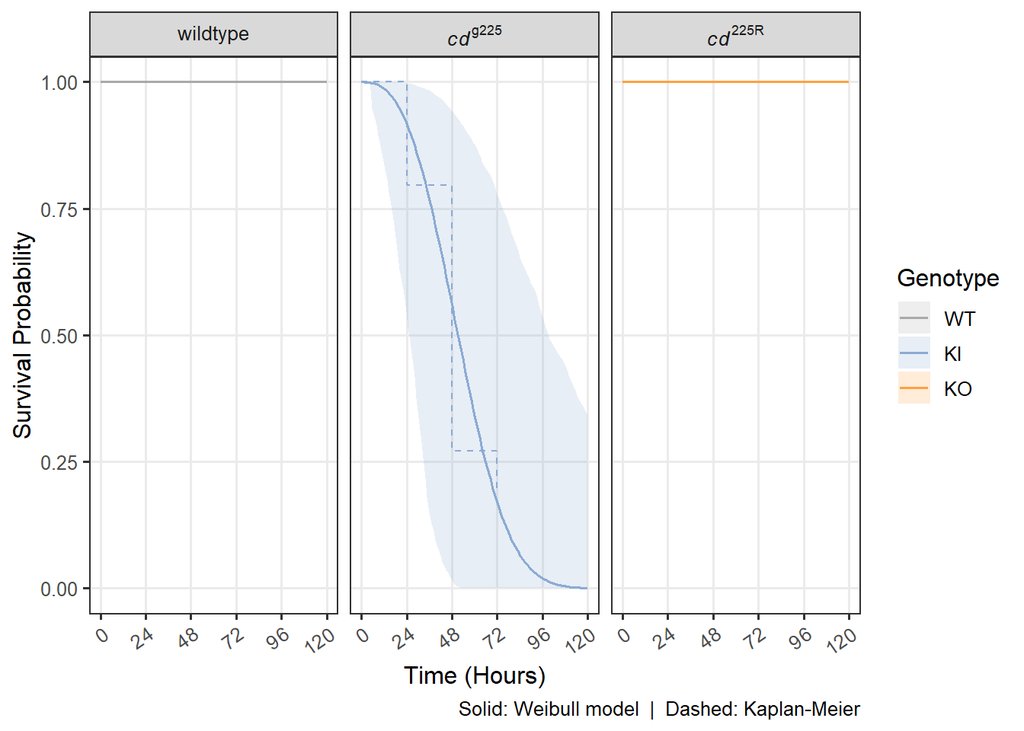

### Survival separated by smurf

```
`r2()` does not support models of class `flexsurvreg`.
```

|  | Surv(hours,survival) |  |  |
| --- | --- | --- | --- |
| Predictors | Estimates | CI | p |
| shape | 3.07 | 1.80 – 5.25 | **<0.001** |
| scale | 90.25 | 0.00 – 99042689238.77 | 0.672 |
| smurf [Smurf-positive] | 0.58 | 0.45 – 0.74 | **<0.001** |
| Observations | 104 |  |  |

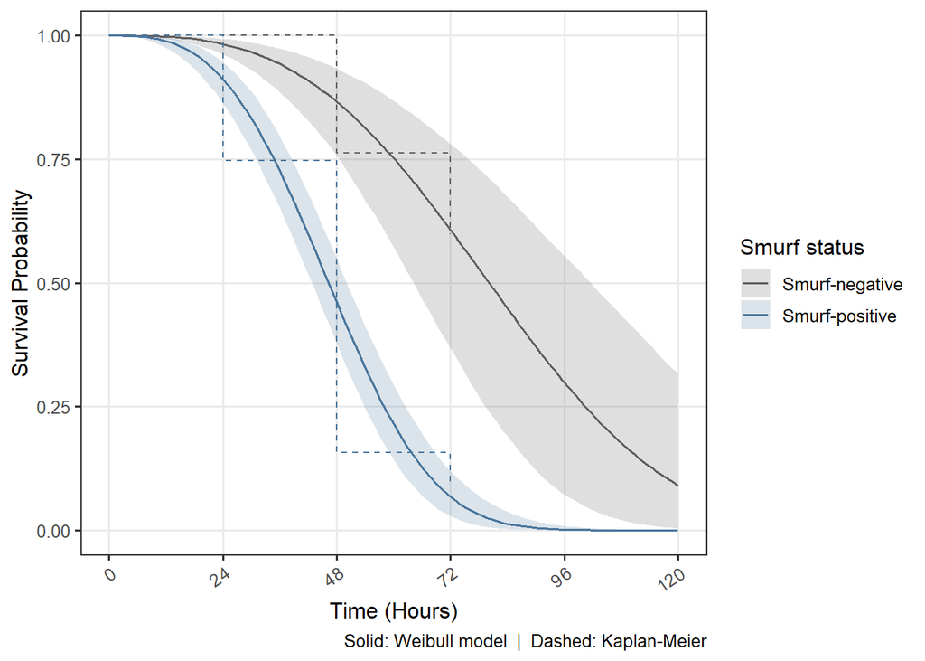